# R Notebook

```r
library(data.table)
library(stringi)

library(stringr)
library(UpSetR)
library(ComplexUpset)


library(ComplexUpset)
library(ggplot2)
```

```r
run_medatada <- fread("/lustre/scratch117/cellgen/team218/gp7/Joe/MicroExonator/run_metadata.tsv")
run_medatada[ , .(Compare_ID, A.cluster_names, B.cluster_names)]
```

| Compare_ID | A.cluster_names | B.cluster_names |
| --- | --- | --- |
| FirstHeart_vs_Primitive | 27 | 32 |
| FistHeart_vs_SecondHeart | 27 | 34 |
| SecondHeart_vs_Miofibro | 34 | 28 |
| Blood_core | 23 | 0 |
| Intermediate_mesoderm | 3 | 35 |
| Intermediate_mesoderm_primordium | 5 | 35 |
| Spinal_cord_progenitors_diff | 30 | 13 |
| Spinal_cord_diff | 6 | 13 |
| Spinal_cord_brain | 30,6,13 | 9,10,12 |
| Neural_crest_anterior | 14 | 21 |

[output cut: 73 more lines]

Thophectoderm_Epiblast SecondHeart_vs_Primitive Primitive_vs_Outflow ReichertMembrane_vs_ViseralEndoderm Early_gastrulation_VE

```r
path_diff <- "/lustre/scratch117/cellgen/team218/gp7/Joe/MicroExonator/Whippet/Delta/Single_Cell/Sig_nodes/"
diff_files <- list.files(path=path_diff, pattern = "*.txt" )

total_delta <- rbindlist(lapply(paste0(path_diff, diff_files), fread), idcol = "origin")
total_delta[, file := factor(origin, labels = basename(diff_files))]
total_delta[, Compare_ID:=str_replace(file, ".txt", "")]


total_delta <- merge(total_delta, run_medatada[ , .(Compare_ID, A.cluster_names, B.cluster_names)], by="Compare_ID")

#total_delta <- total_delta[Compare_ID!="Total_brain_spinal_vs_Total_epiblast_expanded_paga_2"  &
 #                            Compare_ID!="Thophectoderm_Epiblast"  &
#                           Compare_ID!="Primitive_vs_Outflow"  &
#                           Compare_ID!="ReichertMembrane_vs_ViseralEndoderm"  &
#                           Compare_ID!="Early_gastrulation_VE" &
#                              Compare_ID!="ReichertMembrane_vs_Trophectoderm" &
#                             Compare_ID!="ReichertMembrane_vs_Trophectoderm" &
#                             Compare_ID!="LPM_endothelium"  ]


total_delta <- total_delta[Compare_ID %in% run_medatada$Compare_ID, ]


total_delta[ (Probability.mean)==1 & is.na(cdf.beta) & Probability.var==0 & Number>40, `:=`(diff="TRUE", Diff=1) ]
```

```
Coercing 'character' RHS to 'logical' to match the type of the target column (column 17 named 'diff').
```

```r
#fwrite(total_delta[ diff=="TRUE" & cdf.beta<1e-5  , .N ,  by="Gene"], quote=F, sep="\t", file="/lustre/scratch117/cellgen/team218/gp7/Joe/MicroExonator/Whippet/Delta/Single_Cell/Sig_nodes/total_delta.genes.tsv")
```

```r
unique(total_delta$Compare_ID)
```

```
 [1] "Allantois_Endothelium_vs_Whole_blood"      "Allantois_endothelium"                     "Blood_core"                                "Early_caudal_Allantois"
 [5] "Early_caudal_Paraxial_mesoderm"            "Early_caudal_intermediate_primordium"      "Early_caudal_pharyngeal_arches"            "Early_gastrulation_Epi_vs_ExE"
 [9] "Endothelium_primitive_blood"               "ExE_TE_vs_PaE"                             "ExE_TE_vs_VE"                              "FHF_LPM"
[13] "FHF_mesoderm_unknown"                      "FirstHeart_vs_Primitive"                   "FistHeart_vs_SecondHeart"                  "Forebrain_hindbrain"
[17] "Forebrain_spinal_chord_cycling"            "Hindbrain_isthmus_Rhombobomeres"           "Hindbrain_isthmus_spinal_chord_cycling"    "Int_meso1_Pharyngeal_arches"
[21] "Int_meso1_somites"                         "Intermediate_mesoderm"                     "Intermediate_mesoderm_LPM"                 "Intermediate_mesoderm_pharyngeal_arches_1"
[25] "Intermediate_mesoderm_pharyngeal_arches_2" "Intermediate_mesoderm_primordium"          "Intermediate_primordium_allantois"         "Intermediate_primordium_int_mesoderm_2"
[29] "LPM_Allantois"                             "LPM_Myofibroblasts"                        "LPM_SHF"                                   "Mesoderm_vs_Endoderm"
[33] "Mesoderm_vs_Neuroectoderm"                 "Neural_crest_anterior"                     "Neural_crest_vs_Cranial_mesoderm_somites"  "Neural_crest_vs_Forebrain_isthmus"
[37] "Neural_crest_vs_Total_brain"               "Neural_crest_vs_Total_brain_spinal"        "Neural_crest_vs_spinal"                    "Neuroectoderm_vs_Endoderm"
[41] "Node_endoderm"                             "Outflow_tract_surface_ect"                 "Paraxial_int_mesoderm"                     "Paraxial_intermediate_primordium"
[45] "Pharyngeal_arches_1_LPM"                   "Pharyngeal_arches_1_vs_2"                  "Pharyngeal_arches_2_FHF"                   "Pharyngeal_arches_2_LPM"
[49] "Pharyngeal_arches_2_PHT"                   "Pharyngeal_arches_2_cranial_mesoderm"      "Pharyngeal_arches_2_somites"               "Pharyngeal_arches_FHF"
[53] "Pharyngeal_arches_Somites"                 "Pharyngeal_arches_cranial_mesoderm"        "Pharyngeal_arches_int_mesoderm"            "Placodal_Node"
[57] "Placodal_Pro_nephros"                      "Placodal_endoderm"                         "ReichertMembrane_vs_Epiblast"              "Rhobombomers_spinal_cord_cycling"
[61] "Rhombobomeres_spinal_chord_differentiated" "SecondHeart_vs_Miofibro"                   "SecondHeart_vs_Primitive"                  "Somites_cranial_mesoderm"
[65] "Spinal_cord_brain"                         "Spinal_cord_diff"                          "Spinal_cord_differentiated_cycling"        "Spinal_cord_progenitors_diff"
[69] "Streak_Epi65"                              "Streak_Epi75a_Caudal_Epi_E75"              "Streak_Epi75b_Forebrain"                   "Streak_Epi75c_Outflow_tract"
[73] "Streak_Epi75d_Pre-placodal"                "Streak_Epi75e_Dorsal_surface_ecto"         "Streak_caudal_Epi75_Epi75"                 "Streak_caudal_Epi75_caudal_Epi"
[77] "Streak_caudal_Epi75_early_caudal"          "Streak_caudal_Epi75_node"                  "Streak_caudal_interm_meso"                 "Surfact_ect_Placodal"
[81] "Total_brain_spinal_vs_Total_epiblast_2"    "Trophectoderm_vs_Epiblast"                 "blood_all_batches_vs_progenitors"
```

```r
length(unique(total_delta[diff=="TRUE", Coord]))
```

```
[1] 1505
```

```r
total_delta[ diff=="TRUE" , .N ,  by="Gene"]
```

| Gene | N |
| --- | --- |
| ENSMUSG00000037012 | 5 |
| ENSMUSG00000037608 | 1 |
| ENSMUSG00000001151 | 3 |
| ENSMUSG00000069601 | 9 |
| ENSMUSG00000035697 | 1 |
| ENSMUSG00000039835 | 7 |
| ENSMUSG00000019978 | 2 |
| ENSMUSG00000019920 | 2 |
| ENSMUSG00000020097 | 2 |
| ENSMUSG00000001891 | 2 |

[output cut: 755 more lines]

```r
cat(total_delta[ diff=="TRUE" & cdf.beta<1e-5 , .N ,  by="Gene"]$Gene, sep="\n")
```

```
ENSMUSG00000037012
ENSMUSG00000001151
ENSMUSG00000035697
ENSMUSG00000039835
ENSMUSG00000019920
ENSMUSG00000020097
ENSMUSG00000020315
ENSMUSG00000000631
ENSMUSG00000018501
ENSMUSG00000020456
ENSMUSG00000020532
ENSMUSG00000017774
ENSMUSG00000048277
ENSMUSG00000021144
ENSMUSG00000007411
ENSMUSG00000021189
ENSMUSG00000015143
ENSMUSG00000021282
ENSMUSG00000042284
ENSMUSG00000009470
ENSMUSG00000056234
ENSMUSG00000042323
ENSMUSG00000022016
ENSMUSG00000039197
ENSMUSG00000022565
ENSMUSG00000036529
ENSMUSG00000036167
ENSMUSG00000022377
ENSMUSG00000022789
ENSMUSG00000022951
ENSMUSG00000022957
ENSMUSG00000002489
ENSMUSG00000073436
ENSMUSG00000013787
ENSMUSG00000068036
ENSMUSG00000014426
ENSMUSG00000025728
ENSMUSG00000002496
ENSMUSG00000071856
ENSMUSG00000024663
```

[output cut: 240 more lines]

```
ENSMUSG00000057411
ENSMUSG00000040407
ENSMUSG00000031731
ENSMUSG00000034518
ENSMUSG00000031995
ENSMUSG00000057193
MSTRG.8816
ENSMUSG00000042032
ENSMUSG00000024576
ENSMUSG00000022995
ENSMUSG00000033295
ENSMUSG00000028284
ENSMUSG00000040268
ENSMUSG00000025665
ENSMUSG00000028717
```

| Compare_class | Compare_ID | A.cluster_names | B.cluster_names | N | rank | Compare_code |
| --- | --- | --- | --- | --- | --- | --- |
| Composed | Allantois_Endothelium_vs_Whole_blood | 15,7 | 23,39,0,36 | 263 | 1 | C1 |
| Composed | Early_gastrulation_Epi_vs_ExE | 29 | 37,19,26 | 174 | 2 | C2 |
| Composed | Mesoderm_vs_Endoderm | 3,5,35,18 | 25 | 119 | 4 | C4 |
| Composed | Mesoderm_vs_Neuroectoderm | 3,5,35,18 | 12,10,9 | 59 | 7 | C7 |
| Composed | Neural_crest_vs_Cranial_mesoderm_somites | 21,14 | 16,1 | 18 | 11 | C11 |
| Composed | Neural_crest_vs_Total_brain | 21,14 | 9,10,12 | 49 | 8 | C8 |
| Composed | Neural_crest_vs_Total_brain_spinal | 21,14 | 13,30,9,10,6,12 | 158 | 3 | C3 |
| Composed | Neural_crest_vs_spinal | 21,14 | 30,13,6 | 33 | 10 | C10 |
| Composed | Neuroectoderm_vs_Endoderm | 12,10,9 | 25 | 96 | 5 | C5 |
| Composed | Spinal_cord_brain | 30,6,13 | 9,10,12 | 9 | 12 | C12 |

[output cut: 73 more lines]

#Numbers for paper

```r
length(unique(total_delta[Compare_ID %in% included_comparisons & diff==T & Coord %in% SNMs , Coord])) / length(SNMs)
```

```
[1] 0.2771084
```

| Coord | C1 | C10 | C11 | C12 | C2 | C3 | C4 | C5 | C6 | C7 | C8 | C9 | P1 | P10 | P11 | P12 | P13 | P14 | P15 | P16 | P17 | P18 | P19 | P2 | P20 | P21 | P22 | P23 | P24 | … |
| --- | --- | --- | --- | --- | --- | --- | --- | --- | --- | --- | --- | --- | --- | --- | --- | --- | --- | --- | --- | --- | --- | --- | --- | --- | --- | --- | --- | --- | --- | --- |
| 10:108264782-108264833 | FALSE | FALSE | FALSE | FALSE | FALSE | FALSE | FALSE | FALSE | FALSE | FALSE | FALSE | FALSE | FALSE | FALSE | FALSE | TRUE | FALSE | FALSE | FALSE | FALSE | FALSE | FALSE | FALSE | FALSE | FALSE | FALSE | FALSE | FALSE | FALSE | … |
| 10:111494825-111495009 | FALSE | FALSE | FALSE | FALSE | FALSE | FALSE | FALSE | FALSE | FALSE | FALSE | FALSE | FALSE | FALSE | FALSE | FALSE | TRUE | TRUE | FALSE | FALSE | TRUE | FALSE | FALSE | FALSE | FALSE | FALSE | FALSE | FALSE | FALSE | FALSE | … |
| 10:115427305-115427397 | FALSE | FALSE | FALSE | FALSE | FALSE | FALSE | TRUE | TRUE | FALSE | FALSE | FALSE | FALSE | FALSE | FALSE | FALSE | FALSE | FALSE | FALSE | FALSE | FALSE | FALSE | FALSE | FALSE | FALSE | FALSE | FALSE | FALSE | FALSE | FALSE | … |
| 10:117736234-117736270 | FALSE | FALSE | FALSE | FALSE | FALSE | FALSE | FALSE | FALSE | FALSE | FALSE | FALSE | FALSE | FALSE | FALSE | FALSE | FALSE | FALSE | FALSE | FALSE | FALSE | FALSE | FALSE | FALSE | FALSE | FALSE | FALSE | FALSE | FALSE | FALSE | … |
| 10:117736271-117736331 | FALSE | FALSE | FALSE | FALSE | FALSE | FALSE | FALSE | FALSE | FALSE | FALSE | FALSE | FALSE | FALSE | FALSE | FALSE | FALSE | FALSE | FALSE | FALSE | FALSE | FALSE | FALSE | FALSE | FALSE | FALSE | FALSE | FALSE | FALSE | FALSE | … |
| 10:119484983-119484999 | FALSE | FALSE | FALSE | FALSE | FALSE | FALSE | FALSE | FALSE | FALSE | FALSE | FALSE | FALSE | FALSE | FALSE | FALSE | FALSE | FALSE | FALSE | FALSE | FALSE | TRUE | FALSE | FALSE | FALSE | FALSE | FALSE | FALSE | FALSE | FALSE | … |
| 10:119489699-119489732 | FALSE | FALSE | FALSE | FALSE | FALSE | TRUE | FALSE | FALSE | FALSE | FALSE | FALSE | FALSE | FALSE | FALSE | FALSE | FALSE | FALSE | FALSE | FALSE | FALSE | FALSE | FALSE | FALSE | FALSE | FALSE | FALSE | FALSE | FALSE | FALSE | … |
| 10:119497165-119497232 | FALSE | FALSE | FALSE | FALSE | FALSE | TRUE | FALSE | FALSE | FALSE | FALSE | FALSE | FALSE | FALSE | FALSE | FALSE | FALSE | FALSE | FALSE | FALSE | FALSE | FALSE | FALSE | FALSE | FALSE | FALSE | FALSE | FALSE | FALSE | FALSE | … |
| 10:119498077-119498979 | FALSE | FALSE | FALSE | FALSE | FALSE | TRUE | FALSE | FALSE | FALSE | FALSE | FALSE | FALSE | FALSE | FALSE | FALSE | FALSE | FALSE | FALSE | FALSE | FALSE | FALSE | FALSE | FALSE | FALSE | FALSE | FALSE | FALSE | FALSE | FALSE | … |
| 10:119498980-119499091 | FALSE | FALSE | FALSE | FALSE | FALSE | TRUE | FALSE | FALSE | FALSE | FALSE | FALSE | FALSE | FALSE | FALSE | FALSE | FALSE | FALSE | FALSE | FALSE | FALSE | FALSE | FALSE | FALSE | FALSE | FALSE | FALSE | FALSE | FALSE | FALSE | … |

[output cut: 990 more lines]

Calculating the total amount of nodes that are differentially included

```r
length(unique(total_delta[diff=="TRUE" & Compare_ID %in% run_medatada.stats[(Compare_class=="Pairwise" | Compare_ID=="blood_all_batches_vs_progenitors") & Compare_code!="P9"  ,  Compare_ID], Compare_ID]))
```

```
[1] 71
```

```r
length(unique(total_delta[diff=="TRUE" & Compare_ID %in% run_medatada.stats[(Compare_class=="Pairwise" | Compare_ID=="blood_all_batches_vs_progenitors") & Compare_code!="P9"  ,  Compare_ID], Coord]))
```

```
[1] 974
```

```r
diff_nodes <- unique(total_delta[diff=="TRUE" & Compare_ID %in% run_medatada.stats[(Compare_class=="Pairwise" | Compare_ID=="blood_all_batches_vs_progenitors") & Compare_code!="P9"  ,  Compare_ID], .(Coord, Type)])


 diff_nodes[ , .N, by="Type"]
```

| Type | N |
| --- | --- |
| CE | 447 |
| AL | 2 |
| AA | 155 |
| TE | 35 |
| AD | 148 |
| RI | 160 |
| TS | 17 |
| AF | 10 |

```r
 length(unique(total_delta[diff=="TRUE" & Compare_code %in% filtered_compares & Compare_ID %in% run_medatada.stats[(Compare_class=="Pairwise" | Compare_ID=="blood_all_batches_vs_progenitors") & Compare_code!="P9"  ,  Compare_ID], Coord]))
```

```
[1] 662
```

```r
View( total_delta[diff=="TRUE"  & Compare_code %in% filtered_compares &  Compare_ID %in% run_medatada.stats[(Compare_class=="Pairwise" | Compare_ID=="blood_all_batches_vs_progenitors") & Compare_code!="P9"  ,  Compare_ID], .(Coord, Type, Compare_code)][ , .N, by=c("Type", "Compare_code")][ order(Compare_code, -N)])
```

```r
total_delta.type_stats <- total_delta[ diff=="TRUE", .N , by=c("Coord", "Type")][ , .N , by="Type"]

total_diff_number <- total_delta.type_stats[ , sum(N)]

total_delta.type_stats[ , percetage:=(N*100/total_diff_number)]
```

```r
total_delta.type_stats <- total_delta[ diff=="TRUE" & Compare_code %in% filtered_compares, .N , by=c("Compare_code", "Type")]


total_delta.type_stats
```

| Compare_code | Type | N |
| --- | --- | --- |
| P8 | CE | 29 |
| P8 | AL | 1 |
| P8 | AA | 8 |
| P8 | TE | 2 |
| P8 | AD | 1 |
| P8 | RI | 3 |
| P8 | TS | 2 |
| P8 | AF | 3 |
| P5 | AA | 10 |
| P5 | CE | 42 |

[output cut: 75 more lines]

```r
total_delta.type_stats[ , `:=`(rank=frank(-N, ties.method="first"),  Total=sum(N)) , by=c("Compare_code") ]


total_delta.type_stats[ , Percentage:=(N*100/Total)]

total_delta.type_stats[rank==1, ]
```

| Compare_code | Type | N | rank | Total | Percentage |
| --- | --- | --- | --- | --- | --- |
| P8 | CE | 29 | 1 | 49 | 59.18367 |
| P5 | CE | 42 | 1 | 69 | 60.86957 |
| P7 | RI | 22 | 1 | 54 | 40.74074 |
| P2 | CE | 55 | 1 | 108 | 50.92593 |
| P1 | CE | 96 | 1 | 128 | 75.00000 |
| P14 | CE | 13 | 1 | 31 | 41.93548 |
| P13 | CE | 17 | 1 | 38 | 44.73684 |
| P15 | CE | 17 | 1 | 30 | 56.66667 |
| P3 | CE | 63 | 1 | 88 | 71.59091 |
| P12 | CE | 18 | 1 | 40 | 45.00000 |

[output cut: 5 more lines]

```r
total_delta.type_stats[Type=="RI", ]
```

| Compare_code | Type | N | rank | Total | Percentage |
| --- | --- | --- | --- | --- | --- |
| P8 | RI | 3 | 3 | 49 | 6.122449 |
| P5 | RI | 5 | 3 | 69 | 7.246377 |
| P7 | RI | 22 | 1 | 54 | 40.740741 |
| P2 | RI | 8 | 4 | 108 | 7.407407 |
| P1 | RI | 6 | 4 | 128 | 4.687500 |
| P14 | RI | 6 | 2 | 31 | 19.354839 |
| P13 | RI | 5 | 3 | 38 | 13.157895 |
| P15 | RI | 4 | 3 | 30 | 13.333333 |
| P3 | RI | 3 | 5 | 88 | 3.409091 |
| P12 | RI | 8 | 2 | 40 | 20.000000 |

[output cut: 5 more lines]

```r
length(unique(total_delta[diff=="TRUE" & Compare_code %in% filtered_compares, Coord]))
```

```
[1] 662
```

```r
#total_delta.upsetr[, ..cols_filter ]

#which(rowSums(total_delta.upsetr[ , ..filtered_compares])==0)

#total_delta.upsetr[ which(rowSums(total_delta.upsetr[ , ..filtered_compares])==0), Other:="TRUE" ]
#total_delta.upsetr[ which(rowSums(total_delta.upsetr[ , ..filtered_compares])>0), Other:="FALSE" ]
```

```r
ordered_sets <- c(
  rev(run_medatada.stats[Compare_class=="Composed"  & Compare_code %in% filtered_compares, ][ order( c(rank) )]$Compare_code),
  rev(run_medatada.stats[Compare_class=="Pairwise" & Compare_code %in% filtered_compares, ][ order( c(rank) )]$Compare_code)

)




total_delta.upsetr$Type <-  factor( total_delta.upsetr$Type, levels=c( "AA", "AD", "AF", "AL", "BS", "CE", "RI", "TE", "TS") )



upset.2 <- upset(    total_delta.upsetr,
    ordered_sets,
    n_intersections=30,
    min_size=5,
    min_degree=1,
    width_ratio=0.2,
    height_ratio=1.5,


        matrix=(
        intersection_matrix(
            geom=geom_point(
                shape=rep(c( rep('triangle', 7 ), rep('circle', 8)), 405/15),
                size=3.5
           ))),

    sort_intersections_by=c('degree') ,

    set_sizes=(
        upset_set_size(
            geom=geom_bar(
                aes(fill=Type, x=group, ),
                width=0.8
            )  ,
            position='left',
        )),


    name='Intersection of significant splicing nodes between pairwise comparsions',     sort_sets=FALSE)



upset.2
```

```
Error: Aesthetics must be either length 1 or the same as the data (345): shape
Run `rlang::last_error()` to see where the error occurred.
```

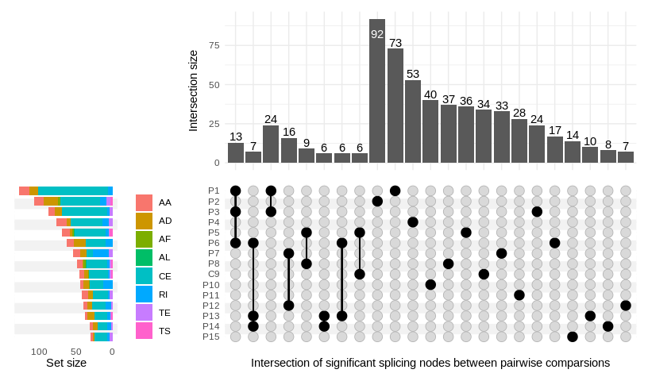

```r
ordered_sets <- c(
  rev(run_medatada.stats[Compare_class=="Composed"  & Compare_code %in% filtered_compares, ][ order( c(rank) )]$Compare_code),
  rev(run_medatada.stats[Compare_class=="Pairwise" & Compare_code %in% filtered_compares, ][ order( c(rank) )]$Compare_code)

)




total_delta.upsetr$Type <-  factor( total_delta.upsetr$Type, levels=c( "AA", "AD", "AF", "AL", "BS", "CE", "RI", "TE", "TS") )



upset.2 <- upset(    total_delta.upsetr,
    rev(filtered_compares),
    n_intersections=30,
    min_size=5,
    min_degree=1,
    width_ratio=0.2,
    height_ratio=1,


        matrix=(
        intersection_matrix(
            geom=geom_point(
                #shape=rep(c( rep('triangle', 7 ), rep('circle', 8)), 405/15),
                size=3.5
           ))),

    sort_intersections_by=c('degree') ,

    set_sizes=(
        upset_set_size(
            geom=geom_bar(
                aes(fill=Type, x=group, ),
                width=0.8
            )  ,
            position='left',
        )),


    name='Intersection of significant splicing nodes between pairwise comparsions',     sort_sets=FALSE)



upset.2
```

```r
upset.2
```

[output not shown]

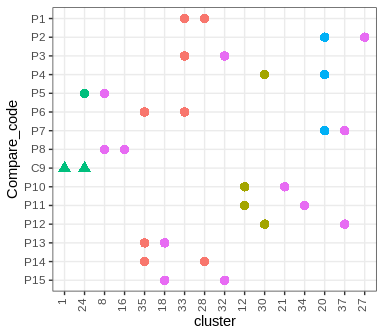

[figure not shown]

```r
upset.1
```

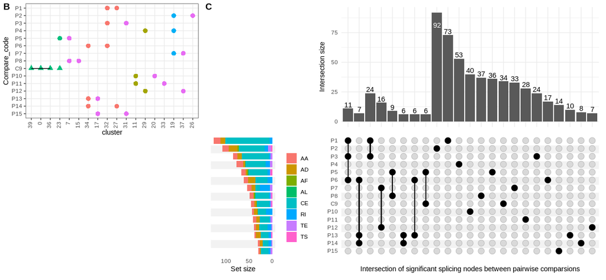

```r
total_delta.gene[grepl("Cask", mgi_symbol) ]
```

| ensembl_gene_id | origin | exon_ID | Gene | Node | Coord | Strand | Type | Psi_A | Psi_B | DeltaPsi | Probability | Complexity | Entropy | file | Compare_ID | Diff | mgi_symbol | wikigene_description | Novel |
| --- | --- | --- | --- | --- | --- | --- | --- | --- | --- | --- | --- | --- | --- | --- | --- | --- | --- | --- | --- |

```r
total_delta.gene[Coord=="7:90182219−90182368",]
```

| ensembl_gene_id | origin | exon_ID | Gene | Node | Coord | Strand | Type | Psi_A | Psi_B | DeltaPsi | Probability | Complexity | Entropy | file | Compare_ID | Diff | mgi_symbol | wikigene_description | Novel |
| --- | --- | --- | --- | --- | --- | --- | --- | --- | --- | --- | --- | --- | --- | --- | --- | --- | --- | --- | --- |

```r
total_delta.gene[ grepl("calmodulin", wikigene_description), .(Compare_ID, Coord, Type, mgi_symbol, wikigene_description )]
```

[output not shown]

```r
gene_table <- data.table(getBM(attributes=c('ensembl_gene_id', "mgi_symbol", "wikigene_description"),filters = 'ensembl_gene_id', values = total_delta[diff=="TRUE", ]$Gene , mart = ensembl_mm))



total_delta.gene <-  merge(total_delta[diff=="TRUE", ], gene_table, by.x="Gene", by.y="ensembl_gene_id")


pseudopool_matrix.zscore.hits.filter
```

| cluster | Coord | n_hits | mean_zscore | mean_delta | Total_Reads | Type | leiden | n_pools | ratio |
| --- | --- | --- | --- | --- | --- | --- | --- | --- | --- |
| 1 | X:7597538-7597732 | 8 | -3.0465701 | -0.1633248 | 44.1900 | CE | 1 | 9 | 0.8888889 |
| 1 | X:7599158-7599336 | 7 | -2.8015274 | -0.1655013 | 29.8100 | CE | 1 | 9 | 0.7777778 |
| 1 | X:7599434-7599500 | 7 | -2.7476722 | -0.1605454 | 32.1400 | CE | 1 | 9 | 0.7777778 |
| 10 | 12:109572546-109572660 | 5 | 2.0009462 | 0.6731006 | 100.0000 | TS | 10 | 6 | 0.8333333 |
| 10 | 18:23804020-23804102 | 5 | -3.3586011 | -0.2214402 | 87.0000 | AA | 10 | 6 | 0.8333333 |
| 10 | 18:23804103-23804221 | 5 | -3.4605458 | -0.2375341 | 151.0000 | CE | 10 | 6 | 0.8333333 |
| 11 | 17:32362793-32362963 | 5 | -2.7098045 | -0.4292419 | 36.4800 | CE | 11 | 6 | 0.8333333 |
| 11 | 4:145091862-145091950 | 5 | -2.3189978 | -0.1943783 | 39.0000 | CE | 11 | 6 | 0.8333333 |
| 11 | 4:145091951-145092072 | 5 | -2.3903249 | -0.1960810 | 40.0000 | AA | 11 | 6 | 0.8333333 |
| 11 | 7:105568619-105568631 | 5 | 3.4345838 | 0.2235213 | 74.0000 | CE | 11 | 6 | 0.8333333 |

[output cut: 990 more lines]

```r
total_delta.gene[, .( Coord, Type, mgi_symbol, wikigene_description, Compare_ID, DeltaPsi.mean, cdf.beta)][order(cdf.beta)][mgi_symbol=="Pkc2"]
```

| Coord | Type | mgi_symbol | wikigene_description | Compare_ID | DeltaPsi.mean | cdf.beta |
| --- | --- | --- | --- | --- | --- | --- |

```r
total_delta.gene.zscore_hits.positive <-  merge(total_delta.gene, pseudopool_matrix.zscore.hits.filter.positive[, .(Coord, cluster, mean_zscore )], by="Coord")
total_delta.gene.zscore_hits.negative <-  merge(total_delta.gene, pseudopool_matrix.zscore.hits.filter.negative[, .(Coord, cluster, mean_zscore )], by="Coord")



total_delta.gene.zscore_hits.positive[ cluster %in% c(35) , .( Coord, Type, cluster, mgi_symbol, wikigene_description, Compare_ID, DeltaPsi.mean, cdf.beta, mean_zscore)][order(-mean_zscore)]
```

| Coord | Type | cluster | mgi_symbol | wikigene_description | Compare_ID | DeltaPsi.mean | cdf.beta | mean_zscore |
| --- | --- | --- | --- | --- | --- | --- | --- | --- |
| 17:46700147-46700149 | AA | 35 | Ppp2r5d | protein phosphatase 2, regulatory subunit B', delta | Int_meso1_Pharyngeal_arches | 0.3949985 | 0.016045283 | 3.144679 |
| 17:46700147-46700149 | AA | 35 | Ppp2r5d | protein phosphatase 2, regulatory subunit B', delta | Int_meso1_somites | 0.4301775 | 0.009167054 | 3.144679 |
| 5:134236700-134237250 | TE | 35 | Gtf2i | general transcription factor II I | Mesoderm_vs_Endoderm | -0.3153493 | 0.018347045 | 2.391447 |
| 9:15306329-15306637 | CE | 35 | Taf1d | TATA-box binding protein associated factor, RNA polymerase I, D | Int_meso1_somites | 0.3461211 | 0.034374852 | 2.057134 |

```r
total_delta.gene.zscore_hits.negative[cdf.beta<1e-5 & !cluster %in% c(36, 26, 0, 12,28) & !mgi_symbol %in% c("Rps24"), ][, .( Coord, Type, cluster, mgi_symbol, wikigene_description, Compare_ID, DeltaPsi.mean, cdf.beta, mean_zscore)][order(-mean_zscore)]
```

| Coord | Type | cluster | mgi_symbol | wikigene_description | Compare_ID | DeltaPsi.mean | cdf.beta | mean_zscore |
| --- | --- | --- | --- | --- | --- | --- | --- | --- |
| 3:9560870-9560961 | RI | 24 | Zfp704 | zinc finger protein 704 | Streak_Epi75a_Caudal_Epi_E75 | 0.2792019 | 2.405066e-06 | -1.980068 |
| 2:26586661-26586681 | CE | 7 | Egfl7 | EGF-like domain 7 | Allantois_endothelium | 0.7914497 | 3.215839e-43 | -2.131724 |
| 2:26586661-26586681 | CE | 7 | Egfl7 | EGF-like domain 7 | Endothelium_primitive_blood | -0.5217162 | 1.551709e-08 | -2.131724 |
| 13:102905649-102905758 | CE | 7 | Mast4 | microtubule associated serine/threonine kinase family member 4 | Allantois_endothelium | 0.6500326 | 1.012300e-71 | -2.167729 |
| 12:80170686-80170766 | CE | 17 | Actn1 | actinin, alpha 1 | Early_caudal_Allantois | 0.3743814 | 5.728801e-12 | -2.255616 |
| 12:80170686-80170766 | CE | 17 | Actn1 | actinin, alpha 1 | Early_caudal_Paraxial_mesoderm | -0.2113594 | 5.027449e-06 | -2.255616 |
| 12:80170686-80170766 | CE | 17 | Actn1 | actinin, alpha 1 | Early_gastrulation_Epi_vs_ExE | -0.4235706 | 5.536432e-06 | -2.255616 |
| 12:80170686-80170766 | CE | 17 | Actn1 | actinin, alpha 1 | Endothelium_primitive_blood | -0.3458990 | 9.909906e-17 | -2.255616 |
| 12:80170686-80170766 | CE | 17 | Actn1 | actinin, alpha 1 | Intermediate_mesoderm_LPM | 0.5985562 | 3.794171e-103 | -2.255616 |
| 12:80170686-80170766 | CE | 17 | Actn1 | actinin, alpha 1 | Intermediate_primordium_allantois | 0.4130656 | 9.070381e-36 | -2.255616 |

[output cut: 119 more lines]

```r
total_delta.gene.zscore_hits.negative[, .( Coord, Type, cluster, mgi_symbol, wikigene_description, Compare_ID, DeltaPsi.mean, cdf.beta, mean_zscore)][order(cdf.beta)]
```

| Coord | Type | cluster | mgi_symbol | wikigene_description | Compare_ID | DeltaPsi.mean | cdf.beta | mean_zscore |
| --- | --- | --- | --- | --- | --- | --- | --- | --- |
| 14:52316043-52316100 | CE | 12 | Sall2 | spalt like transcription factor 2 | Neuroectoderm_vs_Endoderm | -0.6197287 | 1.860897e-115 | -2.172055 |
| 14:24495430-24495432 | CE | 19 | Rps24 | ribosomal protein S24 | Streak_caudal_Epi75_caudal_Epi | -0.2288892 | 2.079515e-111 | -2.688380 |
| 14:24495430-24495432 | CE | 23 | Rps24 | ribosomal protein S24 | Streak_caudal_Epi75_caudal_Epi | -0.2288892 | 2.079515e-111 | -2.058222 |
| 14:24495430-24495432 | CE | 26 | Rps24 | ribosomal protein S24 | Streak_caudal_Epi75_caudal_Epi | -0.2288892 | 2.079515e-111 | -2.946985 |
| 14:24495430-24495432 | CE | 29 | Rps24 | ribosomal protein S24 | Streak_caudal_Epi75_caudal_Epi | -0.2288892 | 2.079515e-111 | -2.146918 |
| 14:24495430-24495432 | CE | 36 | Rps24 | ribosomal protein S24 | Streak_caudal_Epi75_caudal_Epi | -0.2288892 | 2.079515e-111 | -2.747557 |
| 14:24495430-24495432 | CE | 37 | Rps24 | ribosomal protein S24 | Streak_caudal_Epi75_caudal_Epi | -0.2288892 | 2.079515e-111 | -2.823780 |
| 12:80170686-80170766 | CE | 17 | Actn1 | actinin, alpha 1 | Intermediate_mesoderm_LPM | 0.5985562 | 3.794171e-103 | -2.255616 |
| 12:80170686-80170766 | CE | 32 | Actn1 | actinin, alpha 1 | Intermediate_mesoderm_LPM | 0.5985562 | 3.794171e-103 | -2.500072 |
| 2:10056770-10056806 | CE | 32 | Atp5c1 | ATP synthase, H+ transporting, mitochondrial F1 complex, gamma polypeptide 1 | FirstHeart_vs_Primitive | 0.6582348 | 3.794171e-103 | -7.353083 |

[output cut: 482 more lines]

# Z-score

## Positive

9:69998248-69998306 CE 26 Bnip2 cluster 26 Necesary for normal gastrulation in zebrafish (https://scholarbank.nus.edu.sg/handle/10635/37723), but not much is know about this gene in the contex of development

7:28909903-28909988 Actn4 -Cluster 32 -This is exon 8B -8b variant was restricted to the brain, spinal cord, skeletal and cardiac muscle, and smooth muscle-rich tissues (https://portlandpress.com/biochemj/article/452/3/477/46439/An-analysis-of-splicing-actin-binding-properties)

11:94113263-94113301 CE 34 Spag9 Cluster 34 embryonic splice patterns in RNAs regulating cytoskeleton and sarcomere assembly and function including in hearts (https://www.nature.com/articles/srep09042)

19:8756074-8757064 TE 37 Nxf1 Cluster 37 No aparent function in development this gene is key to mRNA export to the cytoplasm and functionally copuleed with SR proteins (http://genesdev.cshlp.org/content/30/5/553.short) The node represent an alternative promoter that is not annotated! Which leads to a longer 5’UTR

5:146465850-146466019 CE 19 Wasf3 WASP family, member 3 Cluster 19 No found to be related with development, but its hihgly involved in cancer

18:61580452-61580475 AD 41 Csnk1a1 casein kinase 1, alpha 1 Cluster 41 This gene is involved in control of selfnewal of epidermal progenitors (https://www.sciencedirect.com/science/article/pii/S1534580717306810) Its splicing its controlde by RBFOX1 https://academic.oup.com/hmg/article/21/19/4171/584744?login=true

1:86351101-86351211 CE 36 Ncl nucleolin Cluster 36 This could be either an autentic intron retention or an snoRNA experssion

12:113133541-113133576 CE 34 Mta1 Both associated with Heart and blood Involved in the plurinet

9:44342221-44342305 CE 0 Hmbs Cluster 0 interesting blood function

15:76195424-76195730 CE 7 Plec Cluster 7 Strongly associated to 7 Citoskeleton Involved in migration and ploriferation of mESC and related with calmodulin regulation https://www.liebertpub.com/doi/full/10.1089/scd.2013.0158?casa_token=LF96Ba4HM-YAAAAA%3AJ2jA4Wrcsp-N4GTYCkZve3WTFgoKfdycn7GOiUGwa9XMmQuCZ8wAhgbjfpD1gxTJBYKY_z7dD0NuEio

7:90182219-90182368 CE 36 Picalm Cluster 36 Essential for Erythroid maduration (https://journals.plos.org/plosone/article?id=10.1371/journal.pone.0031854) Possible regulated by Mbnl1 https://ashpublications.org/blood/article/124/4/598/33336/Muscleblind-like-1-Mbnl1-regulates-pre-mRNA

7:130199807-130199905 CE 20 Fgfr2 Related with plurinet Includes a Ig domain

18:44573502-44574370 CE 19 Mcc mutated in colorectal cancers Strong patterns associated to early gastrulation, blood and brain

4:131937015-131937211 CE 33 Epb41 Cluster 33 This shows a pattern that is not related with blood, but rather with early gastrulation

8:75016222-75016406 CE 29 Hmgxb4 HMG box domain containing 4 Cluster 29 and 19 Splicing of this gene is regulated by hgRNPLL during exit of pluripotency https://www.embopress.org/doi/full/10.15252/embj.2020104729?casa_token=0r_Ejo4NLP4AAAAA%3A3NDrPk4JbK12mCyQ7ZvX9nZpq0HsggmxZb9L-AVE50L2CjsRrhICzGinx-pnEN6zndA4kesJ_e6i

## Negative:

7:28909903-28909988 Actn4 Cluster 32 -Exon 8A which is mutually exclusive with 8B

17:69207870-69207885 AA 26 Epb41l3

14:24495430-24495432 + 14:24495433-24495449 Rps24 -Cluster 36 Co-excluded in blood and early gastrulation This exon skipping lead to an alternative end of this proteing Alternative splicing changes have already been reported to affect this gene after hipoxia treatement (https://rnajournal.cshlp.org/content/26/3/361.full) This exon have been already shown that is regulated during iPSC differentiation using scRNA-seq analyses and PCR validations (https://www.sciencedirect.com/science/article/pii/S1097276517304057) -Rps7, Rpsa and Rpl27a are other ribosomal proteins that have significant events

10:62340013-62340542 CE 0 Hk1 Cluster 0 This is included as result of an alternative promoter, which can lead to hide a mitocondria binding domain, that is embeded on a disordered region.

12:101926087-101926207 CE 26 Atxn3 ataxin 3 This splicing event involves a novel exon!!

14:52316043-52316100 Sall2 -Cluster 12 - Strongly excluded in neuroectoderm. -Plurinet - Transcription factor that seems relevant for eye development. - Required for Neural tube close: https://www.sciencedirect.com/science/article/pii/S0002944010615313?casa_token=Dc_Fs4h1AQ8AAAAA:0ldwbT1t16rgO8IVAByNEIc9nLT1Yka_1pjJhPb7rQhctciovi5o-FNlvt1ZfHO1uc1OsUM3Zg

12:80170686-80170766 CE 28 Actn1 Cluster 28 Skiping of a calcium binding domain!

16:23112351-23112409 CE 34 Eif4a2 skipped on 34 Impacts a translation initiation factor. Important be cause we found other AS on these factors. Introduce a codon stop

# Global

Mesoderm_vs_Neuroectoderm 18:60963600-60963922 AA Camk2a calcium/calmodulin-dependent protein kinase II alpha t change the interaction with BAALC, which it’s embeded into a disordered region. Then also the signal peptide is afected, and this protein would not be translocated by the SRP to the ER… so it would not work a transmebrane protein at all. internal promoter

2:153683608-153683677 /2:153684359-153684477 CE Dnmt3b DNA methyltransferase 3B -This gene is key to pluripotency

14:31113849-31113945 CE Pbrm1 polybromo 1 -Present in PluriNetWork -Chromatin remodeler -Exon repressed in cardiomyocite and in blood -Exon affect a DNA binding motif

X:94114196-94114263 CE Zfx zinc finger protein X-linked

# RBP

```r
node= "18:60963600-60963922"

ggplot() +

        geom_point(data=vert, aes(FA1, FA2)) +
        geom_segment(data=edges, aes(x=FA1.x, y=FA2.x, xend = FA1.y, yend = FA2.y, size=value), colour="grey" ) +
        geom_point(data=pseudopool_matrix.zscore.PAGA[Coord==node, ], aes(FA1, FA2, colour=PSI, size=log(n_cells)), position = position_jitter(w = 2e3, h = 2e3), alpha=0.5 ) +
                theme_bw() +
      geom_text_repel(data = vert.names, colour="black", aes(FA1, FA2),
    box.padding = unit(0.5, 'lines'),
    point.padding = 0.3,
                label=vert.names$cluster )  +

     scale_colour_gradient2(low = "steelblue", midpoint = 0.5, mid = "lightskyblue3", high = "firebrick", na.value = "gray40") +
    scale_size( range = c(0.01, 4)) +

        theme(legend.position = "none", panel.grid.major = element_blank(), panel.grid.minor = element_blank(),
panel.background = element_blank())  +
    theme(axis.title.x=element_blank(),
        axis.text.x=element_blank(),
        axis.ticks.x=element_blank(),
        axis.title.y=element_blank(),
        axis.text.y=element_blank(),
        axis.ticks.y=element_blank(), strip.text.x = element_text(size = 12, face="bold")
        )
```

```
Error in fortify(data) : object 'vert' not found
```

```r
Coord_info["14:24495433-24495449"]
```

```
14:24495433-24495449
       "Rps24 AD 23"
```

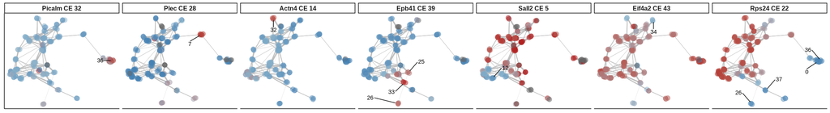

```r
node_vector <- c("7:90182219-90182368",
                 "15:76195424-76195730",
       "7:28909903-28909988",
       "4:131937015-131937211",

       "14:52316043-52316100",
       "16:23112351-23112409",
       "14:24495430-24495432"
      )






PSI_dots <- pseudopool_matrix.zscore.PAGA[Coord %in% node_vector, ]
PSI_dots$Coord <- factor(PSI_dots$Coord, levels=node_vector)

label_data <- do.call("rbind", replicate(7, vert.names, simplify = FALSE))
label_data[,  Coord:=rep(node_vector, times = c(42,42,42,42,42,42,42))]

accepted_labels <- total_delta[Coord %in% node_vector & diff=="TRUE", .(Compare_ID, Coord)]

#accepted_labels <- merge(unique(accepted_labels), unique(run_medatada.AB), by="Compare_ID", allow.cartesian=TRUE)
#label_data.filter <- label_data[paste(Coord, cluster) %in% unique(accepted_labels[ , paste(Coord, cluster)]), ]

accepted_labels <- c(total_delta.gene.zscore_hits.positive[ , paste(Coord, cluster)], total_delta.gene.zscore_hits.negative[ , paste(Coord, cluster)])
label_data.filter <- label_data[paste(Coord, cluster) %in% accepted_labels, ]


label_data.filter$Coord <- factor(label_data.filter$Coord, levels=node_vector)


ggplot() +
       # geom_point(data=vert, aes(FA1, FA2)) +
        geom_segment(data=edges, aes(x=FA1.x, y=FA2.x, xend = FA1.y, yend = FA2.y, size=value), colour="grey" ) +
        geom_point(data=PSI_dots, aes(FA1, FA2, colour=PSI, size=log(n_cells)), position = position_jitter(w = 2e3, h = 2e3), alpha=0.5 ) +

                theme_classic() +
     geom_text_repel(data = label_data.filter, colour="black", aes(FA1, FA2),
    box.padding = unit(1.2, 'lines'),
    point.padding = 0.5,
    max.overlaps=Inf,
                label=label_data.filter$cluster )  +

     scale_colour_gradient2(low = "steelblue", midpoint = 0.5, mid = "lightskyblue3", high = "firebrick", na.value = "gray40") +
    scale_size( range = c(0.01, 4)) +
  xlab("") +
  ylab("") +

    facet_grid(. ~ Coord, labeller = labeller(Coord = Coord_info)) +
        theme(legend.position = "none", panel.grid.major = element_blank(), panel.grid.minor = element_blank(),
panel.background = element_blank())  +
  theme(axis.title.x=element_blank(),
        axis.text.x=element_blank(),
        axis.ticks.x=element_blank(),
        axis.title.y=element_blank(),
        axis.text.y=element_blank(),
        axis.ticks.y=element_blank(), strip.text.x = element_text(size = 12, face="bold")
        )
```

[figure not shown]

```r
node_vector <- c("2:153684359-153684477", "18:60963600-60963922", "2:153683608-153683677"   )





PSI_dots <- pseudopool_matrix.zscore.PAGA[Coord %in% node_vector, ]
PSI_dots$Coord <- factor(PSI_dots$Coord, levels=node_vector)

label_data <- do.call("rbind", replicate(3, vert.names, simplify = FALSE))
label_data[,  Coord:=rep(node_vector, times = c(42,42, 42))]

accepted_labels <- total_delta[Coord %in% node_vector & diff=="TRUE", .(Compare_ID, Coord)]

#accepted_labels <- merge(unique(accepted_labels), unique(run_medatada.AB), by="Compare_ID", allow.cartesian=TRUE)
#label_data.filter <- label_data[paste(Coord, cluster) %in% unique(accepted_labels[ , paste(Coord, cluster)]), ]

accepted_labels <- c(total_delta.gene.zscore_hits.positive[ , paste(Coord, cluster)], total_delta.gene.zscore_hits.negative[ , paste(Coord, cluster)])
label_data.filter <- label_data[paste(Coord, cluster) %in% accepted_labels, ]


label_data.filter$Coord <- factor(label_data.filter$Coord, levels=node_vector)


ggplot() +
       # geom_point(data=vert, aes(FA1, FA2)) +
        geom_segment(data=edges, aes(x=FA1.x, y=FA2.x, xend = FA1.y, yend = FA2.y, size=value), colour="grey" ) +
        geom_point(data=PSI_dots, aes(FA1, FA2, colour=PSI, size=log(n_cells)), position = position_jitter(w = 2e3, h = 2e3), alpha=0.5 ) +

                theme_classic() +
     geom_text_repel(data = label_data, colour="black", aes(FA1, FA2),
    box.padding = unit(0.4, 'lines'),
    point.padding = 0.2,
    max.overlaps=Inf,
                label=label_data$cluster )  +

     scale_colour_gradient2(low = "steelblue", midpoint = 0.5, mid = "lightskyblue3", high = "firebrick", na.value = "gray40") +
    scale_size( range = c(0.01, 4)) +
  xlab("") +
  ylab("") +

    facet_grid( . ~ Coord , labeller = labeller(Coord = Coord_info)) +
        theme(legend.position = "none", panel.grid.major = element_blank(), panel.grid.minor = element_blank(),
panel.background = element_blank())  +
  theme(axis.title.x=element_blank(),
        axis.text.x=element_blank(),
        axis.ticks.x=element_blank(),
        axis.title.y=element_blank(),
        axis.text.y=element_blank(),
        axis.ticks.y=element_blank(), strip.text.x = element_text(size = 12, face="bold")
        )
```

```r
run_medatada.top
```

| Compare_ID | Compare_code | cluster | Compare_class | side | Class |
| --- | --- | --- | --- | --- | --- |
| Allantois_endothelium | P8 | 15 | Pairwise | A | Other |
| Blood_subdivition | P9 | 0 | Pairwise | A | Erythroid |
| Endothelium_primitive_blood | P5 | 7 | Pairwise | A | Other |
| ExE_TE_vs_PaE | P7 | 19 | Pairwise | A | Extra embryonic |
| ExE_TE_vs_VE | P2 | 19 | Pairwise | A | Extra embryonic |
| FirstHeart_vs_Primitive | P1 | 27 | Pairwise | A | Cardiac |
| Pharyngeal_arches_2_PHT | P3 | 31 | Pairwise | A | Other |
| SecondHeart_vs_Primitive | P6 | 34 | Pairwise | A | Cardiac |
| Trophectoderm_vs_Epiblast | P4 | 19 | Pairwise | A | Extra embryonic |
| Early_gastrulation_Epi_vs_ExE | C1 | 29 | Composed | A | Epiblast |

[output cut: 46 more lines]

```r
movies = as.data.frame(ggplot2movies::movies)
genres = colnames(movies)[18:24]
movies[genres] = movies[genres] == 1
t(head(movies[genres], 3))
```

```
                1     2     3
Action      FALSE FALSE FALSE
Animation   FALSE FALSE  TRUE
Comedy       TRUE  TRUE FALSE
Drama        TRUE FALSE FALSE
Documentary FALSE FALSE FALSE
Romance     FALSE FALSE FALSE
Short       FALSE FALSE  TRUE
```

```r
movies[movies$mpaa == '', 'mpaa'] = NA
movies = na.omit(movies)
```